# Assignment1

Oscar Hsieh

November 15, 2019

## R Markdown

The data is from 51490 games from a game called League of Legends. Even though there are more than 61 variables, most of them have similar attributes (For example t1_ban1, t1_ban2 and t1_ban3 are variables that ban a certain character in that order).

This dataset was collected using the Riot Games API, which makes it easy to lookup and collect information on a users ranked history and collect their games.

```r
myData <- read.csv("games.csv")
head(myData)
```

```
##       gameId creationTime gameDuration seasonId winner firstBlood
## 1 3326086514 1.504279e+12         1949        9      1          2
## 2 3229566029 1.497849e+12         1851        9      1          1
## 3 3327363504 1.504360e+12         1493        9      1          2
## 4 3326856598 1.504349e+12         1758        9      1          1
## 5 3330080762 1.504554e+12         2094        9      1          2
## 6 3287435705 1.501668e+12         2059        9      1          2
##   firstTower firstInhibitor firstBaron firstDragon firstRiftHerald
## 1          1              1          1           1               2
## 2          1              1          0           1               1
## 3          1              1          1           2               0
## 4          1              1          1           1               0
## 5          1              1          1           1               0
## 6          2              1          1           2               0
##   t1_champ1id t1_champ1_sum1 t1_champ1_sum2 t1_champ2id t1_champ2_sum1
```

[output cut: 69 more lines]

### Purpose of the explanatory analysis

It is always crucial to have a goal in mind when doing data analysis, so for this assignment, we will focus on how to successfully predict whether a team wins.

### Cleaning and preprocessing data

-Converting the variables into the right types -Changing 1 and 2 into team 1 and team 2 when necessary -Drop columns that are not relevant for this assignment -Some columns can be removed using domain knowledge. For instance, selecting spells is often a fixed procedure so it won’t fluctate the overall win ratio.

```r
###Converting the variables into the right types
myData <- myData %>% mutate_at(vars(4:ncol(myData)), as.character)

###Replace 1 and 2 with team 1 and team 2
myData <- myData %>% mutate(winner = replace(winner, winner ==1,"team 1"),
                  firstBlood = replace(firstBlood, firstBlood ==1,"team 1"),
                  firstTower = replace(firstTower, firstTower ==1,"team 1"),
                  firstInhibitor = replace(firstInhibitor, firstInhibitor ==1,"team 1"),
                  firstBaron = replace(firstBaron, firstBaron ==1,"team 1"),
                  firstDragon = replace(firstDragon, firstDragon ==1,"team 1"),
                  winner = replace(winner, winner ==2,"team 2"),
                  firstBlood = replace(firstBlood, firstBlood ==2,"team 2"),
                  firstTower = replace(firstTower, firstTower ==2,"team 2"),
                  firstInhibitor = replace(firstInhibitor, firstInhibitor ==2,"team 2"),
                  firstBaron = replace(firstBaron, firstBaron ==2,"team 2"),
                  firstDragon = replace(firstDragon, firstDragon ==2,"team 2"))

###Dropping unncessary column(s)
myData <- myData %>% select(-c(2, 4, 13, 14, 16, 17, 19, 20, 22, 23, 25, 26, 31:36, 38, 39, 41, 42, 44, 45, 47, 48, 50, 51, 56:61))

head(myData)
```

```
##       gameId gameDuration winner firstBlood firstTower firstInhibitor
## 1 3326086514         1949 team 1     team 2     team 1         team 1
## 2 3229566029         1851 team 1     team 1     team 1         team 1
## 3 3327363504         1493 team 1     team 2     team 1         team 1
## 4 3326856598         1758 team 1     team 1     team 1         team 1
## 5 3330080762         2094 team 1     team 2     team 1         team 1
## 6 3287435705         2059 team 1     team 2     team 2         team 1
##   firstBaron firstDragon firstRiftHerald t1_champ1id t1_champ2id
## 1     team 1      team 1               2           8         432
## 2          0      team 1               1         119          39
## 3     team 1      team 2               0          18         141
## 4     team 1      team 1               0          57          63
## 5     team 1      team 1               0          19          29
## 6     team 1      team 2               0          40         141
##   t1_champ3id t1_champ4id t1_champ5id t1_towerKills t1_inhibitorKills
```

[output cut: 27 more lines]

So lets do some analysis on the data

First of all, let’s see the win rate of the teams: Team 1 is blue side, while team 2 is red side. Looking at the graph, it seems like team 1 has won more games, but not by a huge margin.

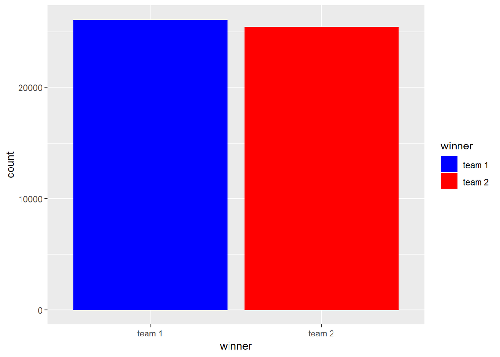

```r
ggplot(data = myData, aes(x = winner, fill = winner)) +
  geom_bar() +
  scale_fill_manual(values=c("blue", "red"))
```

```r
winners <- myData %>%
  count(winner) %>%
  mutate(winPercentage = prop.table(n))
winners
```

```
## # A tibble: 2 x 3
##   winner     n winPercentage
##   <chr>  <int>         <dbl>
## 1 team 1 26077         0.506
## 2 team 2 25413         0.494
```

The table shows that the winning percentage has around 1% difference, this means that on a specific side won’t win you more games.

Next, let’s see the impact of taking the first turret of the game

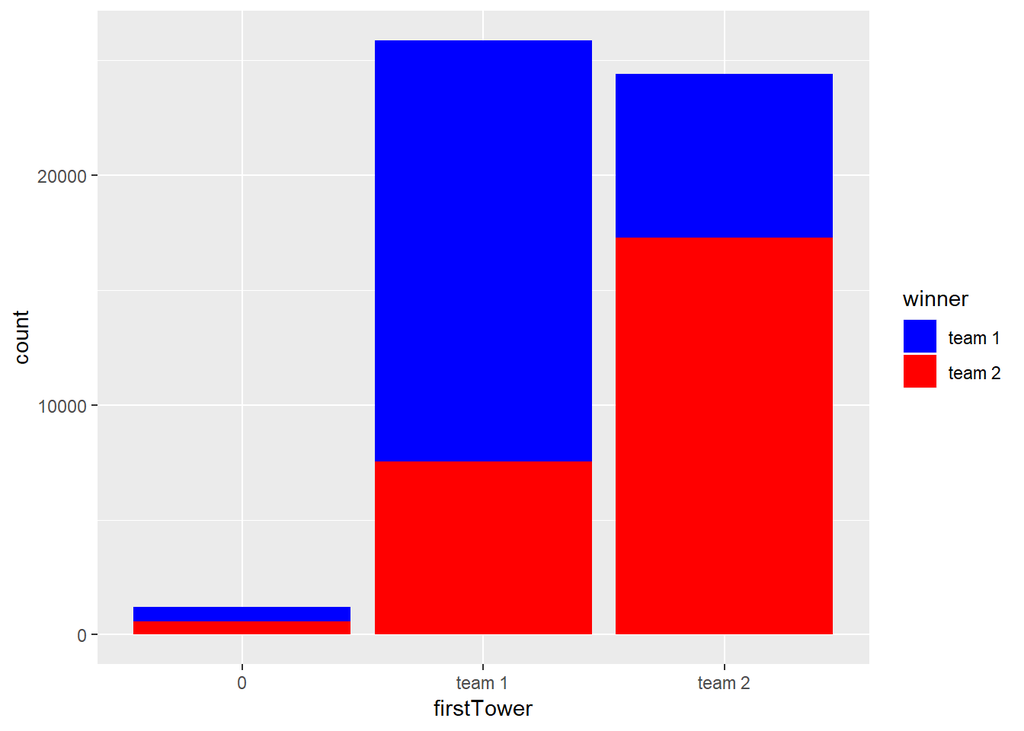

```r
ggplot(data = myData, aes(x = firstTower, fill = winner)) +
  geom_bar() +
  scale_fill_manual(values=c("blue", "red"))
```

It seems like taking turret has quite an impact on winning the game. Though, it makes sense since it is a rare case that a losing team takes first turret, so the team already has an advantage before taking the turret.

The 0 turret means an early surrender, this means that someone didn’t properly connect to the game and the game is disbanded.

Next, let’s see if the characters have a different win ratio. But before we analyze it, we need to transform the dataset since the crucial information isn’t shown on the original data like black and white.

First of all, we divide the dataset into team 1 and team 2 with their corresponding characters for each match. Also, we assign the result of the match with the corresponding row.

Then, we combine the two datasets and group the characters with the same ID so we can see how many times the character lost or won. Finally, dividing the number of times the character won by the total times played, we have the winning percentage of the characters.

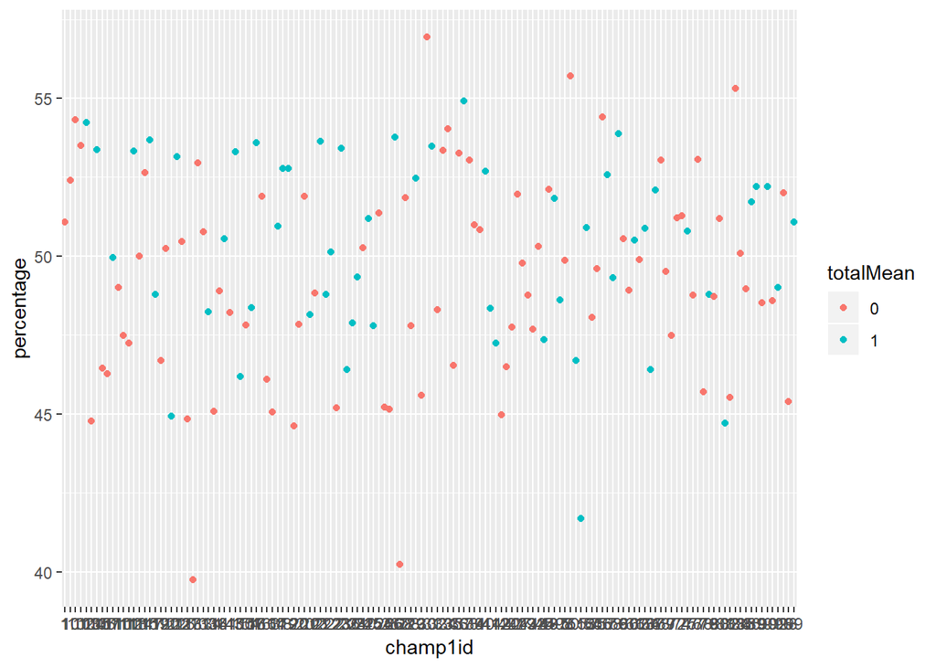

```r
team1Win <- myData %>%
  ###Get the players of the team and which team won for team 1
  select(winner, t1_champ1id, t1_champ2id, t1_champ3id, t1_champ4id, t1_champ5id) %>%
  ###Change the variable to whether the team won or lost
  mutate(winner = case_when(winner == "team 1"~ 1,
                            winner == "team 2" ~ 0,
                            TRUE ~ 2)) %>%
  ###Rename the variables so we can combine rows later
  rename(champ1id = t1_champ1id, champ2id = t1_champ2id, champ3id = t1_champ3id, champ4id = t1_champ4id, champ5id = t1_champ5id)


team2Win <- myData %>%
  ###Get the players of the team and which team won for team 2
  select(winner, t2_champ1id, t2_champ2id, t2_champ3id, t2_champ4id, t2_champ5id) %>%
  ###Change the variable to whether the team won or lost
  mutate(winner = case_when(winner == "team 1"~ 0,
                            winner == "team 2" ~ 1,
                            TRUE ~ 2)) %>%
  ###Rename the variables so we can combine rows later
  rename(champ1id = t2_champ1id, champ2id = t2_champ2id, champ3id = t2_champ3id, champ4id = t2_champ4id, champ5id = t2_champ5id)

champWin <- bind_rows(team1Win, team2Win)



###Get frequency
champStats <- champWin %>%
  group_by(champ1id, winner) %>%
  tally() %>%
  ###Get the total number of games played for each character
  group_by(champ1id) %>%
  mutate(total = sum(n))%>%
  ###Get the winning percentage
  mutate(percentage = n/total * 100) %>%
  filter(winner == 1) %>%
  mutate(totalMean = case_when(total>746 ~1,
                               total<=746~0,
                               TRUE ~2)) %>%
  mutate_at(6, as.character)

ggplot(data = champStats, aes(x = champ1id, y = percentage, colour = totalMean)) + geom_point()
```

As the results show, there is a relatively huge difference between the characters, with the lowest less than 40% and the highest above 56%. So we need to keep this variable in mind when creating a prediction model.

Do characters that occur more frequently have a higher percentage of winning the game? (0 = smaller than the mean, 1 = greater than the mean) Looking at the graph, I doubt it.

Now let’s see how much of an impact first blood has on the game. First blood means the first team killing an enemy character

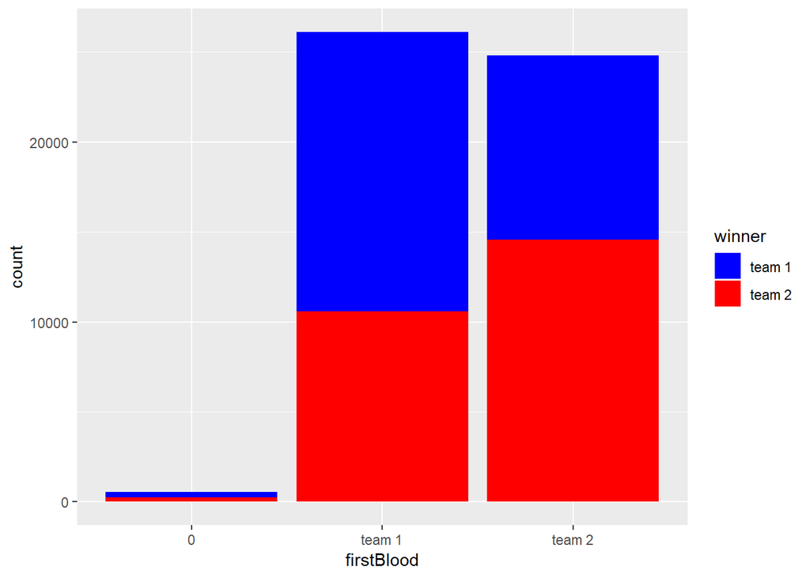

```r
ggplot(data = myData, aes(x = firstBlood, fill = winner)) +
  geom_bar() +
  scale_fill_manual(values=c("blue", "red"))
```

Even though first blood gives a team an advantage, it seems like it isn’t big enough to get a greater lead than people think. One of the reasons I can think of is due to the fact that the game has implemented some elements that stop games from snowballing, so teams are able to come back even when they are sightly behind.

```r
test <- chisq.test(myData$winner, myData$firstBlood)
```

So we will have to take a closer look at this variable.

In this game, an objective called “Baron” increases the power of the team that takes it. Let’s see how this objective improves the chance of winning:

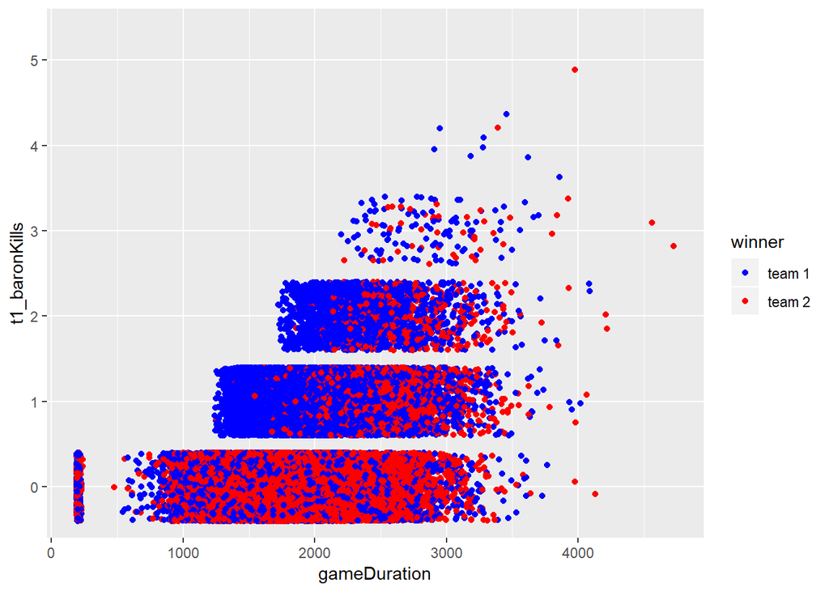

```r
ggplot(myData, aes(x =gameDuration, y = t1_baronKills , colour = winner)) +geom_jitter() +
  scale_color_manual(values=c("blue", "red"))
```

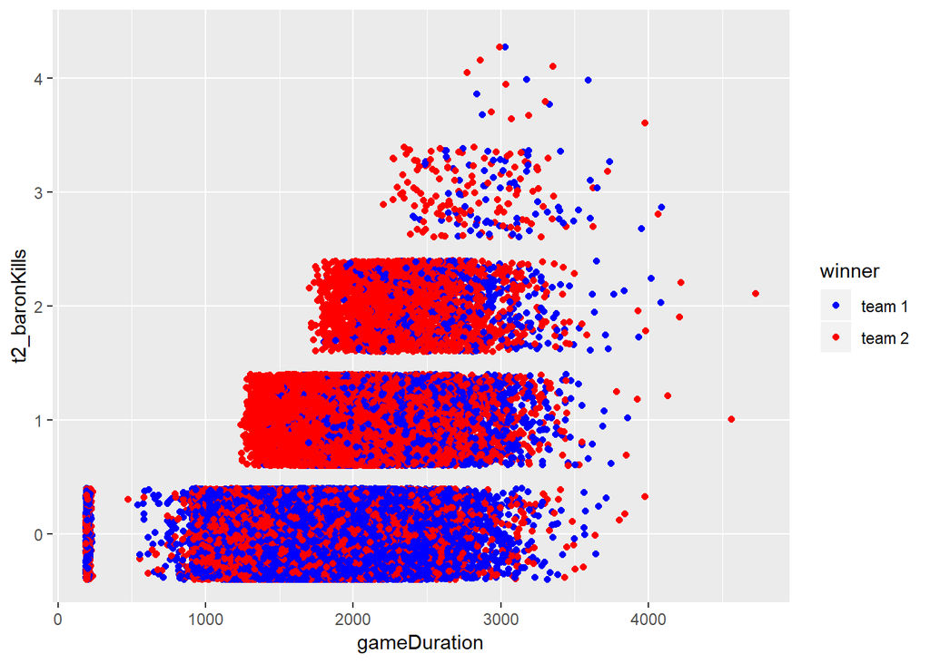

```r
ggplot(myData, aes(x =gameDuration, y = t2_baronKills , colour = winner)) +geom_jitter() +
  scale_color_manual(values=c("blue", "red"))
```

So according to this graph, taking barons will increase the chance of winning, but you also need to end as soon as possible before the opposite team catches up.

Next, we are going to make a prediction on which team wins based on the variables in the dataset.

At first, I wanted to use random forest, but since there are too many categorical variables, R needs to calculate 2^{1447 - 1} - 1 splits, which is computational too heavy for Random forest in R.

By using multinomial logistic regression, we can set the max weight in the parameter to prevent the model not able to handle all the weights. Even though it makes sense not to do it with a small dataset because nothing sensible will come out with only a limited observation. However, with more than 50k observations (And more than 30k in training set) it is worth a try to see how well the model predicts.

```r
confusionMatrix(result, test$winner)
```

```
## Confusion Matrix and Statistics
##
##           Reference
## Prediction team 1 team 2
##     team 1   6566    258
##     team 2    246   6279
##
##                Accuracy : 0.9622
##                  95% CI : (0.9589, 0.9654)
##     No Information Rate : 0.5103
##     P-Value [Acc > NIR] : <2e-16
##
##                   Kappa : 0.9245
##  Mcnemar's Test P-Value : 0.6241
##
##             Sensitivity : 0.9639
##             Specificity : 0.9605
##          Pos Pred Value : 0.9622
##          Neg Pred Value : 0.9623
##              Prevalence : 0.5103
##          Detection Rate : 0.4919
##    Detection Prevalence : 0.5112
##       Balanced Accuracy : 0.9622
##
##        'Positive' Class : team 1
##
```